# R Notebook to explore cherry blossom 10 mile race data

# about the data

The Cherry Blossom 10 Mile Run is a road race held in Washington, D.C. in April each year. (The name comes from the famous cherry trees that are in bloom in April in Washington.) The results of this race are published. This data frame contains the results from the 2005 race.

The dataframe, called TenMileRace, represents all 8636 runners and includes the following variables:

state: State of residence of runner.

time: Official time (in seconds) from starting gun to finish line.

net: The recorded time (in seconds) from when the runner crossed the starting line to when the runner crossed the finish line. This is generally less than the official time because of the large number of runners in the race: it takes time to reach the starting line after the gun has gone off.

age: Age of runner in years.

sex: A factor with levels F M.

# load libraries

```r
library(psych)
library(tidyverse)
```

# read in dataframe

```r
population <- read.csv("TenMileRace.csv")
```

# describe variables

```r
describe(population)
```

|  | vars | n | mean | sd | median | trimmed | mad | min | max | range | skew | kurtosis | se |
| --- | --- | --- | --- | --- | --- | --- | --- | --- | --- | --- | --- | --- | --- |
| ID | 1 | 8636 | 4318.50 | 2493.14 | 4318.5 | 4318.50 | 3200.93 | 1 | 8636 | 8635 | 0.00 | -1.20 | 26.83 |
| state* | 2 | 8636 | 39.18 | 18.07 | 42.0 | 40.48 | 22.24 | 1 | 62 | 61 | -0.40 | -1.33 | 0.19 |
| time | 3 | 8636 | 5813.15 | 1038.35 | 5806.5 | 5795.28 | 985.19 | 2816 | 10603 | 7787 | 0.24 | 0.43 | 11.17 |
| net | 4 | 8636 | 5599.07 | 969.66 | 5555.0 | 5566.00 | 904.39 | 2814 | 10536 | 7722 | 0.44 | 0.81 | 10.43 |
| age | 5 | 8636 | 36.86 | 10.60 | 35.0 | 36.02 | 10.38 | 10 | 87 | 77 | 0.66 | -0.04 | 0.11 |
| sex* | 6 | 8636 | 1.50 | 0.50 | 1.0 | 1.50 | 0.00 | 1 | 2 | 1 | 0.00 | -2.00 | 0.01 |

```r
NA
```

# explore the principles of the sampling distribution

## store population mean

```r
mean_net_time = mean(population$net)
mean_net_time
```

```
[1] 5599.065
```

```r
# get time in minutes
mean_net_time/60
```

```
[1] 93.31776
```

## create a histogram of net time across all people in the population

### in ggplot2

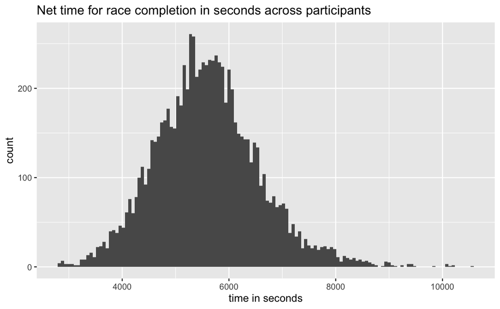

```r
ggplot(population, aes(x = net)) +
  geom_histogram(binwidth = 60) +
  labs (title = "Net time for race completion in seconds across participants", x = "time in seconds")
```

### in base r

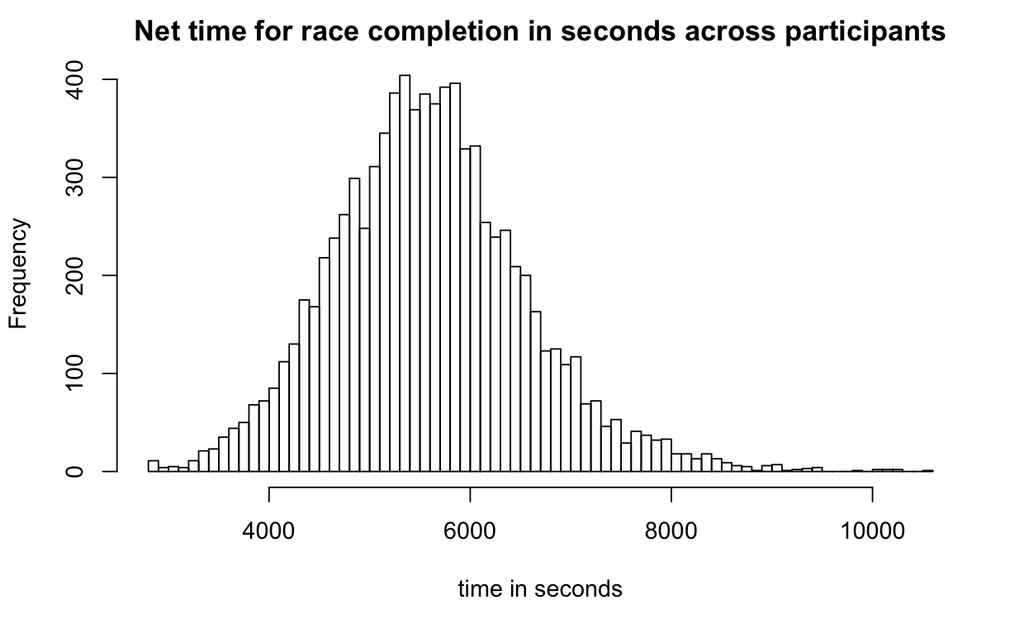

```r
hist(population$net, breaks = 60, main = "Net time for race completion in seconds across participants", xlab = "time in seconds" )
```

## draw 5 random samples from the population

```r
sample1 <- sample_n(population, 50, replace = TRUE)
sample2 <- sample_n(population, 50, replace = TRUE)
sample3 <- sample_n(population, 50, replace = TRUE)
sample4 <- sample_n(population, 50, replace = TRUE)
sample5 <- sample_n(population, 50, replace = TRUE)
```